# Homework 6: Zero Inflation and Negative Binomials

Jamie Ash

due: 2021-10-06

```r
infile <- "..\\data\\"
bugs <- read.csv(paste(infile, "collembola_revised.csv", sep = ""))
```

# 1 Negative Binomial

First use a negative binomial model to ask whether total Collembola count (column total.count) changes with temperature treatment (column temp.treatment), and/or with predator treatment (column predators), and whether the effect of predators changes with temperature. Although we used the function glm.nb() in the MASS package previously, use the function glmmTMB() here, because later we will compare this model to others fit with this function. Plot fitted effects and perform likelihood ratio tests on the relevant terms. To perform marginal tests you will want to compare pairs of models using the function anova(). Previously we used the function Anova() (the capitalized and uncapitalized functions are different) to automate this process, but this function returns a less accurate test for glmmTMB (a Wald test). So, for each term you want to test, compare a model with this term to a model without this term. How do you interpret the results at this stage?

## 1.1 Answer

When comparing models using anova:

1. There is no difference between the full model with predator-temperature interaction and the restricted model without predator-temperature interaction (chi-spqr = 0.53). Predators likely do not have an effect on the relationship between prey count and temperature.
2. When comparing `total.prey ~ temp` and `total.prey ~ temp + preds` a chi-sqr coefficient of $0.34$ is received, meaning there predators likely do not have a strong effect on prey count.
3. When comparing `total.prey ~ pred` and `total.prey ~ temp + preds` a chi-sqr coefficient of $1.075e-06$ is received, meaning temperature likely has a strong effect on prey count.

Lastly, the dispersion coefficient is very large, $1.79e+03$, for all tests using a negative binomial model. There is likely zero inflation occurring.

### 1.1.1 ANOVA and GLM results

```r
# No errors with zeros removed
bugs$preds <- bugs$Pred1 + bugs$Pred2*2
bugs$preds <- as.factor(bugs$preds)
#bugs <- subset(bugs, !total.prey == 0)

mod_in    = glmmTMB(total.prey ~ temp + preds + preds:temp,
                  data = bugs, family = "nbinom1")
mod_no    = glmmTMB(total.prey ~ temp + preds,
                  data = bugs, family = "nbinom1")
mod_temp  = glmmTMB(total.prey ~ temp,
                  data = bugs, family = "nbinom1")
mod_pred  = glmmTMB(total.prey ~ preds,
                  data = bugs, family = "nbinom1")
summary(mod_in)
```

```
##  Family: nbinom1  ( log )
## Formula:          total.prey ~ temp + preds + preds:temp
## Data: bugs
##
##      AIC      BIC   logLik deviance df.resid
##    701.6    720.5   -341.8    683.6       51
##
##
## Dispersion parameter for nbinom1 family (): 1.79e+03
##
## Conditional model:
##             Estimate Std. Error z value Pr(>|z|)
## (Intercept)  6.83201    0.42550  16.057   <2e-16 ***
## temp        -0.85149    0.38625  -2.205   0.0275 *
## preds1      -0.34210    0.55794  -0.613   0.5398
## preds2       0.08647    0.55042   0.157   0.8752
## preds3       0.27197    0.53195   0.511   0.6092
## temp:preds1  0.04279    0.54790   0.078   0.9377
## temp:preds2 -0.77238    0.64990  -1.188   0.2347
## temp:preds3  0.02828    0.51945   0.054   0.9566
## ---
## Signif. codes:  0 '***' 0.001 '**' 0.01 '*' 0.05 '.' 0.1 ' ' 1
```

```r
anova(mod_no, mod_temp) # compare predors + temperature to temperature
```

```
## Data: bugs
## Models:
## mod_temp: total.prey ~ temp, zi=~0, disp=~1
## mod_no: total.prey ~ temp + preds, zi=~0, disp=~1
##          Df    AIC    BIC  logLik deviance Chisq Chi Df Pr(>Chisq)
## mod_temp  3 695.14 701.42 -344.57   689.14
## mod_no    6 697.83 710.40 -342.92   685.83 3.305      3     0.3469
```

```r
anova(mod_no, mod_pred) # compare predors + temperature to predetors
```

```
## Data: bugs
## Models:
## mod_pred: total.prey ~ preds, zi=~0, disp=~1
## mod_no: total.prey ~ temp + preds, zi=~0, disp=~1
##          Df    AIC    BIC  logLik deviance  Chisq Chi Df Pr(>Chisq)
## mod_pred  5 719.62 730.09 -354.81   709.62
## mod_no    6 697.83 710.40 -342.92   685.83 23.789      1  1.075e-06 ***
## ---
## Signif. codes:  0 '***' 0.001 '**' 0.01 '*' 0.05 '.' 0.1 ' ' 1
```

```r
anova(mod_no, mod_in)   # compare predetor-temperature interaction to no interac
```

```
## Data: bugs
## Models:
## mod_no: total.prey ~ temp + preds, zi=~0, disp=~1
## mod_in: total.prey ~ temp + preds + preds:temp, zi=~0, disp=~1
##        Df    AIC    BIC  logLik deviance  Chisq Chi Df Pr(>Chisq)
## mod_no  6 697.83 710.40 -342.92   685.83
## mod_in  9 701.63 720.48 -341.81   683.63 2.2062      3     0.5307
```

### 1.1.2 Model effect plotted

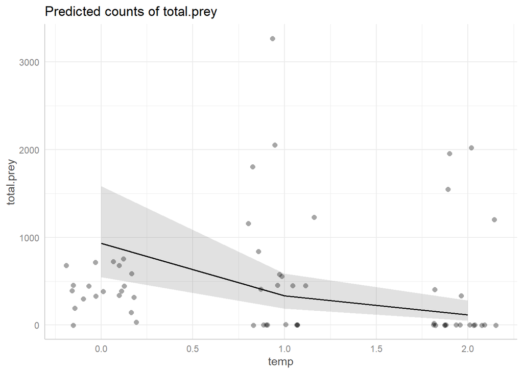

```r
plot(ggeffect(mod_in)$temp,  add = TRUE)
```

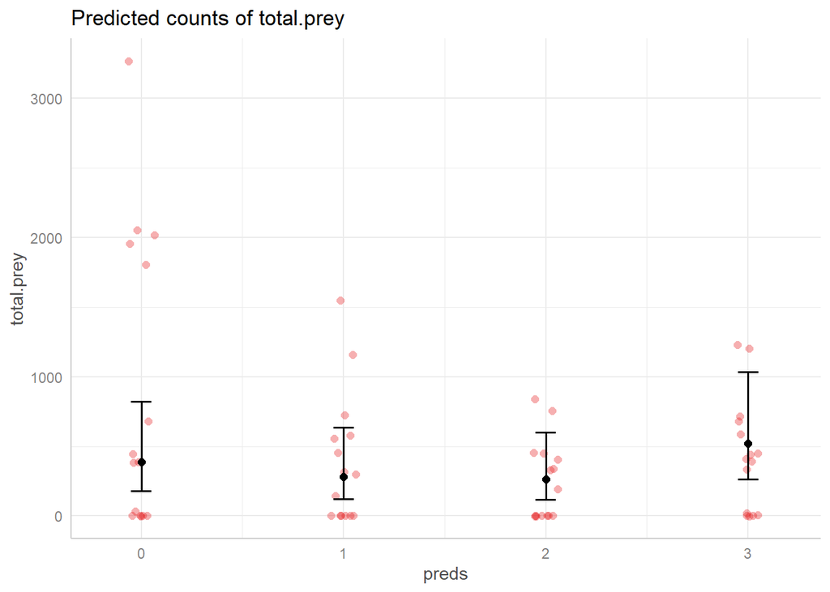

```r
plot(ggeffect(mod_no)$preds, add = TRUE)
```

# 2 Zero Inflated Negative Binomial

A large proportion of the data are zeros, and it may be the case that processes controlling abundance are different from processes controlling ‘extra’ zeros if, in fact, there are extra zeros. Use glmmTMB to fit two more models: a zero inflated poisson model and a zero inflated negative binomial model. In the count model include all the terms from the previous model. In the model for the extra zeros don’t include any predictors for now. Use AIC to compare the three models (negative binomial, zero inflated poisson, zero inflated negative binomial). Which model best fits the data? Using the zero inflated negative binomial model, perform new marginal likelihood ratio tests (using anova()) on the terms in the count model. How have the results changed from the simple negative binomial model?

## 2.1 Answer

The first tab is the results for the anova on the zero inflated Poisson model, the negative binomial model and the zero inflated negative binomial model. The second tab is the results for the marginal likelihood ratio tests using the zero inflated negative binomial model. Last is the effects plot for the zero inflated negative binomial model

### 2.1.1 ANOVA and GLM Resluts

```r
# negative binomial model
mod_nbnom  = glmmTMB(total.prey ~ temp + preds + preds:temp,
                  data = bugs,
                  family = "nbinom1")
# Count model. Including all predictors in zero inflation model
mod_pois0  = glmmTMB(total.prey ~ temp + preds + preds:temp,
              data = bugs,
              ziformula = ~ 1,
              family = "poisson")
# Extra zeros model. Including all predictors.
mod_binom0 = glmmTMB(total.prey ~ temp + preds + preds:temp,
              data = bugs,
              ziformula = ~ 1,
              family = "nbinom1")

anova(mod_pois0, mod_binom0, mod_nbnom)
```

```
## Data: bugs
## Models:
## mod_pois0: total.prey ~ temp + preds + preds:temp, zi=~1, disp=~1
## mod_nbnom: total.prey ~ temp + preds + preds:temp, zi=~0, disp=~1
## mod_binom0: total.prey ~ temp + preds + preds:temp, zi=~1, disp=~1
##            Df    AIC    BIC  logLik deviance    Chisq Chi Df Pr(>Chisq)
## mod_pois0   9 9671.3 9690.1 -4826.7   9653.3
## mod_nbnom   9  701.6  720.5  -341.8    683.6 8969.673      0  < 2.2e-16 ***
## mod_binom0 10  665.6  686.5  -322.8    645.6   38.023      1  6.991e-10 ***
## ---
## Signif. codes:  0 '***' 0.001 '**' 0.01 '*' 0.05 '.' 0.1 ' ' 1
```

### 2.1.2 Zero Inflated Negative Binomial

```r
#bugs <- subset(bugs, !bugs$total.prey == 0)

mod_in   = glmmTMB(total.prey ~ temp + preds + preds:temp,
                     data = bugs,
                     ziformula = ~ 1,
                    family = "nbinom1")
mod_no   = glmmTMB(total.prey ~ temp + preds,
                     data = bugs,
                     ziformula = ~ 1,
                     family = "nbinom1")
mod_temp = glmmTMB(total.prey ~ temp,
                     data = bugs,
                     ziformula = ~ 1,
                     family = "nbinom1")
mod_pred = glmmTMB(total.prey ~ preds,
                     data = bugs,
                     ziformula = ~ 1,
                     family = "nbinom1")

anova(mod_no, mod_in)
```

```
## Data: bugs
## Models:
## mod_no: total.prey ~ temp + preds, zi=~1, disp=~1
## mod_in: total.prey ~ temp + preds + preds:temp, zi=~1, disp=~1
##        Df    AIC    BIC  logLik deviance  Chisq Chi Df Pr(>Chisq)
## mod_no  7 674.06 688.72 -330.03   660.06
## mod_in 10 665.60 686.55 -322.80   645.60 14.455      3   0.002347 **
## ---
## Signif. codes:  0 '***' 0.001 '**' 0.01 '*' 0.05 '.' 0.1 ' ' 1
```

```r
anova(mod_no, mod_temp) # compare predors + temperature to temperature
```

```
## Data: bugs
## Models:
## mod_temp: total.prey ~ temp, zi=~1, disp=~1
## mod_no: total.prey ~ temp + preds, zi=~1, disp=~1
##          Df    AIC    BIC  logLik deviance  Chisq Chi Df Pr(>Chisq)
## mod_temp  4 677.31 685.68 -334.65   669.31
## mod_no    7 674.06 688.72 -330.03   660.06 9.2479      3    0.02617 *
## ---
## Signif. codes:  0 '***' 0.001 '**' 0.01 '*' 0.05 '.' 0.1 ' ' 1
```

```r
anova(mod_no, mod_pred)
```

```
## Data: bugs
## Models:
## mod_pred: total.prey ~ preds, zi=~1, disp=~1
## mod_no: total.prey ~ temp + preds, zi=~1, disp=~1
##          Df    AIC    BIC  logLik deviance  Chisq Chi Df Pr(>Chisq)
## mod_pred  6 678.40 690.96 -333.20   666.40
## mod_no    7 674.06 688.72 -330.03   660.06 6.3368      1    0.01183 *
## ---
## Signif. codes:  0 '***' 0.001 '**' 0.01 '*' 0.05 '.' 0.1 ' ' 1
```

### 2.1.3 Zero Inflated Effects Plots

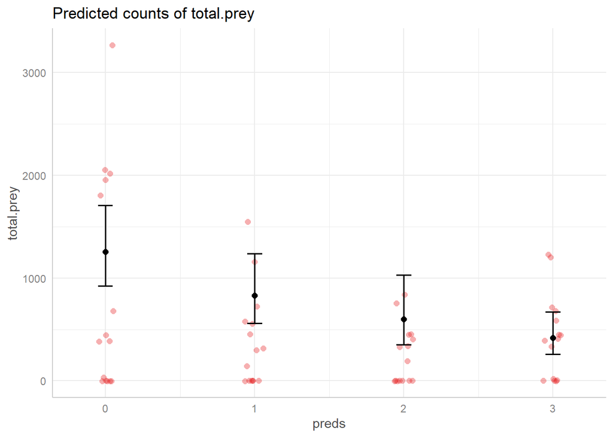

```r
plot(ggeffect(mod_in)$preds, add= TRUE)
```

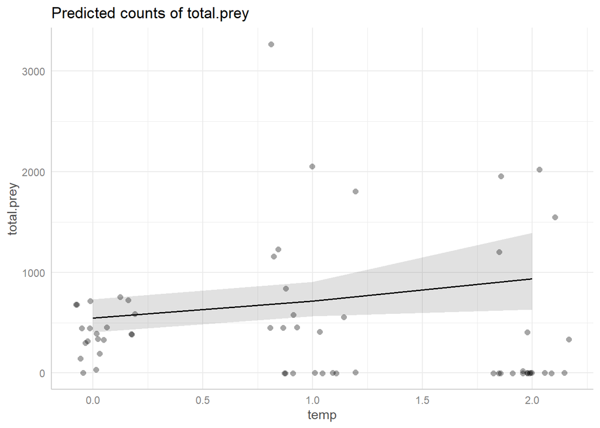

```r
plot(ggeffect(mod_in)$temp, add= TRUE)
```

# 3 Lumped Predators Zero-Inf-Neg-Binomial

Based on the effects plots it seems like the three treatments with predators (HA, HM, HA+HM) may not be very different in their effect on the prey. Let’s test the effect of predators, but treating all treatments with predators as the same. I have re-coded the predator treatment in the column predators.lumped. Fit a zero inflated negative binomial model using predators.lumped instead of predators, and plot fitted effects and perform likelihood ratio tests as before. How do these results compare to what you saw previously? Why do you think the results have changed? How do you interpret these patterns?

## 3.1 Answer

Compared to the zero inflated negative binomial model, the no-interaction model, `total.prey ~ temp + predators.lumped`, vs the interaction model `total.prey ~ temp + predators.lumped + predators.lumped:temp` is still significant but the effects of temperature on prey count is no longer significant (p = 0.054). Well its almost significant anyhow. All predictors are now significant or almost significant.

### 3.1.1 Lumped Zero Inflated Negative Binomial

```r
# convert form character to factor for model
bugs$predators.lumped <- as.factor(bugs$predators.lumped)

mod_in   = glmmTMB(total.prey ~ temp + predators.lumped + predators.lumped:temp,
                     data = bugs,
                     ziformula = ~ 1,
                    family = "nbinom1")
mod_no   = glmmTMB(total.prey ~ temp + predators.lumped,
                     data = bugs,
                     ziformula = ~ 1,
                     family = "nbinom1")
mod_temp = glmmTMB(total.prey ~ temp,
                     data = bugs,
                     ziformula = ~ 1,
                     family = "nbinom1")
mod_pred = glmmTMB(total.prey ~ predators.lumped,
                     data = bugs,
                     ziformula = ~ 1,
                     family = "nbinom1")
#summary(mod_in)
anova(mod_no, mod_temp) # compare predors + temperature to temperature
```

```
## Data: bugs
## Models:
## mod_temp: total.prey ~ temp, zi=~1, disp=~1
## mod_no: total.prey ~ temp + predators.lumped, zi=~1, disp=~1
##          Df    AIC    BIC  logLik deviance  Chisq Chi Df Pr(>Chisq)
## mod_temp  4 677.31 685.68 -334.65   669.31
## mod_no    5 673.81 684.28 -331.90   663.81 5.4983      1    0.01903 *
## ---
## Signif. codes:  0 '***' 0.001 '**' 0.01 '*' 0.05 '.' 0.1 ' ' 1
```

```r
anova(mod_no, mod_pred) # compare predors + temperature to predetors
```

```
## Data: bugs
## Models:
## mod_pred: total.prey ~ predators.lumped, zi=~1, disp=~1
## mod_no: total.prey ~ temp + predators.lumped, zi=~1, disp=~1
##          Df    AIC    BIC  logLik deviance  Chisq Chi Df Pr(>Chisq)
## mod_pred  4 675.51 683.89 -333.75   667.51
## mod_no    5 673.81 684.28 -331.90   663.81 3.7007      1    0.05439 .
## ---
## Signif. codes:  0 '***' 0.001 '**' 0.01 '*' 0.05 '.' 0.1 ' ' 1
```

```r
anova(mod_no, mod_in)   # compare predetor-temperature interaction to no interac
```

```
## Data: bugs
## Models:
## mod_no: total.prey ~ temp + predators.lumped, zi=~1, disp=~1
## mod_in: total.prey ~ temp + predators.lumped + predators.lumped:temp, zi=~1, disp=~1
##        Df    AIC    BIC logLik deviance Chisq Chi Df Pr(>Chisq)
## mod_no  5 673.81 684.28 -331.9   663.81
## mod_in  6 666.01 678.57 -327.0   654.01 9.801      1   0.001744 **
## ---
## Signif. codes:  0 '***' 0.001 '**' 0.01 '*' 0.05 '.' 0.1 ' ' 1
```

### 3.1.2 Lumped Zero Inflated Effects Plots

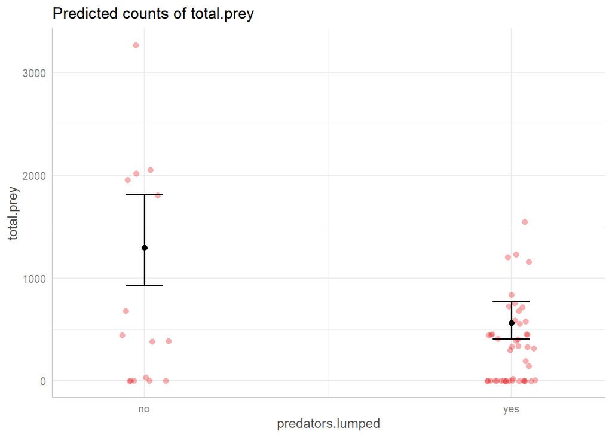

```r
plot(ggeffect(mod_in)$predators.lumped, add = TRUE)
```

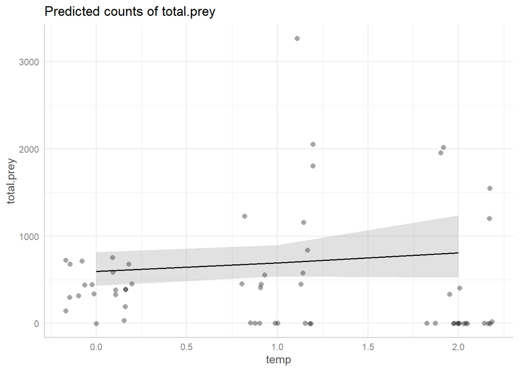

```r
plot(ggeffect(mod_in)$temp, add = TRUE)
```

# 4 Model the zeros

Finally, we have not considered that the ‘extra’ zeros could themselves vary by treatment. Take the zero inflated negative binomial model from #3 and add in terms for temperature, predators.lumped, and the interaction between these treatments. Use likelihood ratio tests to test these terms. The various packages for plotting fitted effects do not (to my knowledge) have a convenient way to plot zero-inflated effects (although this could be done ‘manually’ by extracting model predictions). Instead, look at the model coefficients returned by summary() to interpret whats going on with the extra zeros. In this case the output is most intepretable if you use a model that removes the non-significant terms. What is the pattern in the extra zeros according to this model? How does this pattern differ from the patterns in the count model?

## 4.1 Answer

I chose the zero inflated negative binomial model with the ‘extra’ zeros only varying with temperature to interoperate the summary() results, because I found predators.lumped and predators.lumped:temp to have a very non-significant relationship with the extra zero’s.

The anova() results for models incorporating ‘extra zero’ variation…

1. The `predators.lumped:temp` interaction term is very insignificant (chi = 0.93)
2. Temperature is very significant (chi = 3.0e-05)
3. Predetors.lumped is very insignificant (chi = 0.85)

Using the `ziformula = ~temp` model I found that the extra zero’s scale positively with temperature. That is as temperature rises, the chance of receiving an ‘extra zero’ increases. The other models assumed extra zero’s were evenly distributed across treatment types (I think).

### 4.1.1 ANOVA results

```r
# I think this is equivilent to doing a mixed model with an Identity term for
# each ziformula predictor
mod_in   = glmmTMB(total.prey ~ temp + predators.lumped + predators.lumped:temp,
                 ziformula = ~ temp + predators.lumped + predators.lumped:temp,
                 data = bugs,
                 family = "nbinom1")
mod_no  = glmmTMB(total.prey ~ temp + predators.lumped + predators.lumped:temp,
                 ziformula = ~ temp + predators.lumped,
                 data = bugs,
                 family = "nbinom1")
mod_temp = glmmTMB(total.prey ~ temp + predators.lumped + predators.lumped:temp,
                 ziformula = ~ temp,
                 data = bugs,
                 family = "nbinom1")
mod_pred = glmmTMB(total.prey ~ temp + predators.lumped + predators.lumped:temp,
                 ziformula = ~ predators.lumped,
                 data = bugs,
                 family = "nbinom1")

anova(mod_in, mod_no)
```

```
## Data: bugs
## Models:
## mod_no: total.prey ~ temp + predators.lumped + predators.lumped:temp, zi=~temp + predators.lumped, disp=~1
## mod_in: total.prey ~ temp + predators.lumped + predators.lumped:temp, zi=~temp + predators.lumped + predators.lumped:temp, disp=~1
##        Df   AIC    BIC logLik deviance  Chisq Chi Df Pr(>Chisq)
## mod_no  8 652.6 669.36 -318.3    636.6
## mod_in  9 654.6 673.44 -318.3    636.6 0.0065      1     0.9357
```

```r
anova(mod_no, mod_pred)
```

```
## Data: bugs
## Models:
## mod_pred: total.prey ~ temp + predators.lumped + predators.lumped:temp, zi=~predators.lumped, disp=~1
## mod_no: total.prey ~ temp + predators.lumped + predators.lumped:temp, zi=~temp + predators.lumped, disp=~1
##          Df    AIC    BIC  logLik deviance  Chisq Chi Df Pr(>Chisq)
## mod_pred  7 667.98 682.64 -326.99   653.98
## mod_no    8 652.60 669.36 -318.30   636.60 17.382      1  3.057e-05 ***
## ---
## Signif. codes:  0 '***' 0.001 '**' 0.01 '*' 0.05 '.' 0.1 ' ' 1
```

```r
anova(mod_no, mod_temp)
```

```
## Data: bugs
## Models:
## mod_temp: total.prey ~ temp + predators.lumped + predators.lumped:temp, zi=~temp, disp=~1
## mod_no: total.prey ~ temp + predators.lumped + predators.lumped:temp, zi=~temp + predators.lumped, disp=~1
##          Df    AIC    BIC  logLik deviance  Chisq Chi Df Pr(>Chisq)
## mod_temp  7 650.64 665.30 -318.32   636.64
## mod_no    8 652.60 669.36 -318.30   636.60 0.0333      1     0.8552
```

```r
# I think this is the right model to summary for zero inflation effect
summary(mod_temp)
```

```
##  Family: nbinom1  ( log )
## Formula:          total.prey ~ temp + predators.lumped + predators.lumped:temp
## Zero inflation:              ~temp
## Data: bugs
##
##      AIC      BIC   logLik deviance df.resid
##    650.6    665.3   -318.3    636.6       53
##
##
## Dispersion parameter for nbinom1 family ():  379
##
## Conditional model:
##                          Estimate Std. Error z value Pr(>|z|)
## (Intercept)               6.41347    0.25866  24.795  < 2e-16 ***
## temp                      0.75413    0.17421   4.329  1.5e-05 ***
## predators.lumpedyes      -0.03283    0.30587  -0.107  0.91454
## temp:predators.lumpedyes -0.80065    0.24483  -3.270  0.00107 **
## ---
## Signif. codes:  0 '***' 0.001 '**' 0.01 '*' 0.05 '.' 0.1 ' ' 1
##
## Zero-inflation model:
##             Estimate Std. Error z value Pr(>|z|)
## (Intercept)  -2.4804     0.6645  -3.733 0.000189 ***
## temp          1.6108     0.4507   3.574 0.000352 ***
## ---
## Signif. codes:  0 '***' 0.001 '**' 0.01 '*' 0.05 '.' 0.1 ' ' 1
```